# Intro to Sha Package for Sleep and Health Analysis

Yunrou Gong

2017-12-18

# Introduction

The *Sha* package is used for analysing sleep duration and other atrributes related to life health. The name **Sha** is the abbreviation of Sleep and Health Analysis. We may have curious about weather sleep duration will be influenced by the weight, tempreture, activities, day of the week, and heart rate. Intuitively, sleep time and the other attributes are not that correlated. But, we could use this package to conduct detail analysis to answer intereting questions, which may be counter intuitive. Additionally, I also wonder wheather having pet or not will affect the other features. Basicly, the activities will increase correspondingly by having a dog as you will have to do dog walking at least once a day. We can also conduct some interesting analysis to see how your pet will influence on your life, such as sleeping duration, body weight.

# Description of Original Dataset

In order to discover the attributes that may have some associate with our personal sleep time, I choose to collect of health data of myself via ‘googlesheets’, which I made it published so you can fetch this dataset via “googlesheets” package. I believe that the attributes set well represent my interets on the research question. The measurement of the attributes are also important, which will be detail mentioned below.

```r
library("googlesheets")
googlekey <- gs_url("https://docs.google.com/spreadsheets/d/1KdOw0FIxY2Kt8UgY16F3UMQSC7KJaBgtmewNZUGuLY8/edit#gid=0",lookup = FALSE,visibility = "public")
mydata <- gs_read(googlekey, skip = 3)
```

```r
knitr::kable(head(mydata), format = "markdown", align = 'c')
```

| Date | DayofWeek | Weight | SleepDuration | Tempreture | Activity | HeartRate | HavingDog |
| --- | --- | --- | --- | --- | --- | --- | --- |
| 09/11/2017 | Mon | 43.5 | 7.33 | 15 | 1541 | 74 | No |
| 09/12/2017 | Tue | 44.0 | 8.17 | 18 | 8331 | 93 | No |
| 09/13/2017 | Wed | 44.9 | 6.00 | 19 | 4473 | 72 | No |
| 09/14/2017 | Thu | 44.5 | 7.00 | 22 | 2924 | 66 | No |
| 09/15/2017 | Fri | 44.7 | 6.00 | 21 | 6721 | 79 | No |
| 09/16/2017 | Sat | 43.9 | 12.00 | 22 | 26 | 77 | No |

The collected dataset contains 8 variables related to one individual’s sleep and health data and recoded each observation daily. The following is the variable explanation and how I measure them:

1. Date: in format of month/date/year started from Sep.11 2017
2. DayofWeek: the name of the day during a week (Mon,Tue,Wed,Thu,Fri,Sat,Sun)
3. Weight: body weight in kg measured at erery morning when wake up using the same weighing machine
4. SleepDuration: total sleep time (hour) per night measured by “Sleep Cycle”" app on iphone
5. Tempreture: daily average tempreture in Celsius from website https://www.wunderground.com/history/airport/KROC/2013/12/17/MonthlyHistory.html
6. Activity: a measurement of activity in steps via iphone ‘health’ app
7. HeartRate: heart rate in beats per minute (bpm) measured every morning when wake up via “Sleep Cycle”" app on iphone
8. HavingDog: weather you have dog or not

# Data Cleaning

### Generate a New Variable from column “DayofWeek”

Intuitively, weekday should have similar pattern on sleep duration compared to that of weekend. So we could generate a new variable name as “DayType” to classify each day as weekday or weekend. The more convinient way is to use library **tidyverse** as showing below.

```r
library(tidyverse)
mydata <- mydata %>%
  mutate(DayType = ifelse(DayofWeek %in% c("Sat", "Sun"), "Weekend", "Weekday")) %>%
  select(-DayofWeek)
```

```r
#assign the variable name with units of measurement
sch <- c("Date", "Weight(kg)", "Sleep Duration(hr)", "Tempreture(°C)", "Activity(steps)",
         "Heart Rate(bpm)","Having Dog", "Day Type")
knitr::kable(head(mydata, 10), col.names = sch, align = "c")
```

[output not shown]

# Explotory Data Analysis

## Basic Statistics and useful information

Here, we are going to use “tidyverse” library to manupilate the “mydata” dataset and get the useful information.

```r
n <- mydata %>%
  summarize(n = n())
firstday <- mydata$Date[1]
lastday <- mydata$Date[length(mydata$Date)]
avg_st <- round(mean(mydata$SleepDuration),2)
percent_avg_st <- round(avg_st/24,4)*100
```

There are 99 observations in the **mydata** dataset recoded from the date of 09/11/2017 to 12/18/2017. The average of my sleep time per day is approximately 8 hour, which account for 33.33 % time a day.

```r
count2 <- mydata %>%
  group_by(DayType) %>%
  tally()
```

During this period, there are 71 weekdays, 28 weekends. We are going to find out the average sleep duration on weekday and on weekend and arrange them to see which group has longer sleep duration.

```r
sleep_by_day <- mydata %>%
  group_by(DayType) %>%
  summarise(avg_sleep = mean (SleepDuration)) %>%
  mutate(avg_sleep = round (avg_sleep, 2)) %>%
  arrange(desc(avg_sleep))
```

The average of sleep duration per day in weekend is 9.19 hour, which is longer than the weekday sleep time on average, which is 7.52 hour based on our existing data. It sounds very natually as I had no classes on weekend, so I may get up late.

```r
# Import the package *sha*
library(sha)
```

### Box plot

We could also make box plot to visulise the differences of sleep duration between weekday and weekend by using *plot_box* function. It will also show you how disperse the data is distributed , how skew the distribution may be, and also tell you the outliers in the dataset.

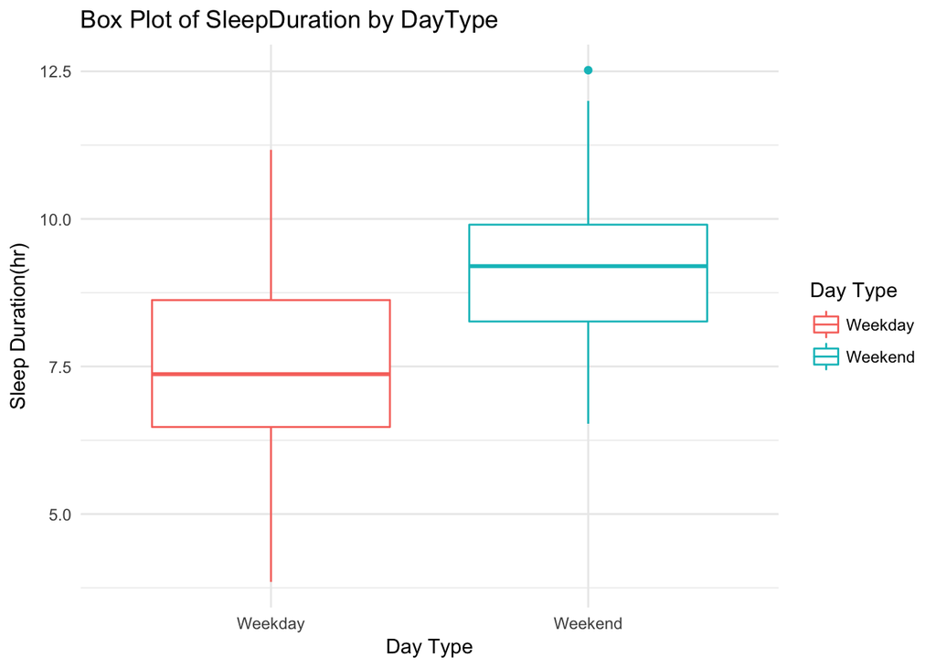

```r
plot_box(mydata, x = "DayType", y= "SleepDuration")
```

From the above boxplot, it tell us that the average sleep time by day in weekday is less than that in weekend, and there is one outlier in weekend group. I will not remove this outlier from the dataset, as I think this value represent my sleep pattern in some days.

To make the catergorical variables as factor variables for following analysis.

```r
mydata$DayType <- as.factor(mydata$DayType)
mydata$HavingDog <- as.factor(mydata$HavingDog)
```

## Scatter plot

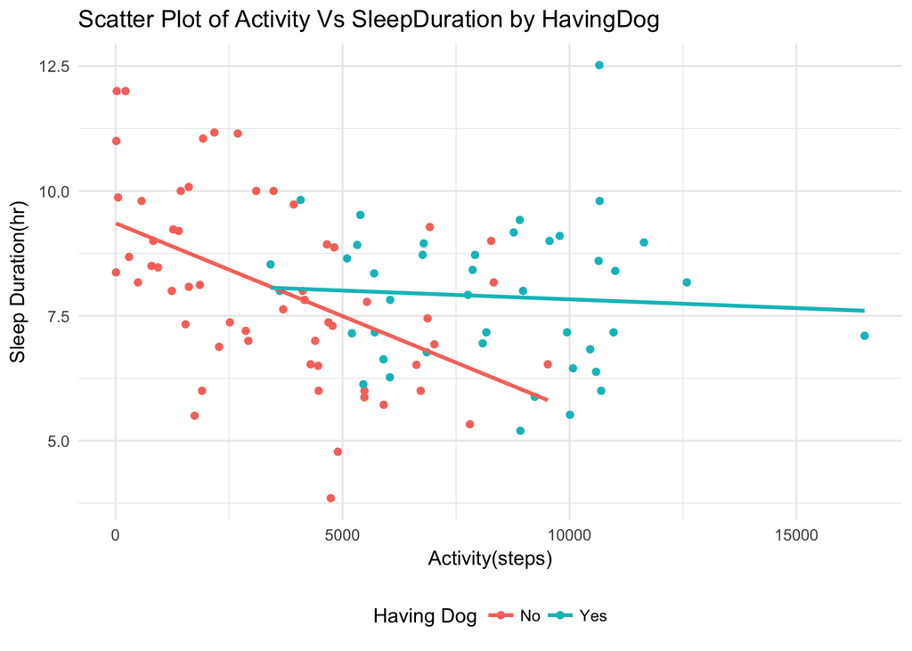

```r
plot_scatter(data = mydata,x = "Activity",y = "SleepDuration", color = "HavingDog")
```

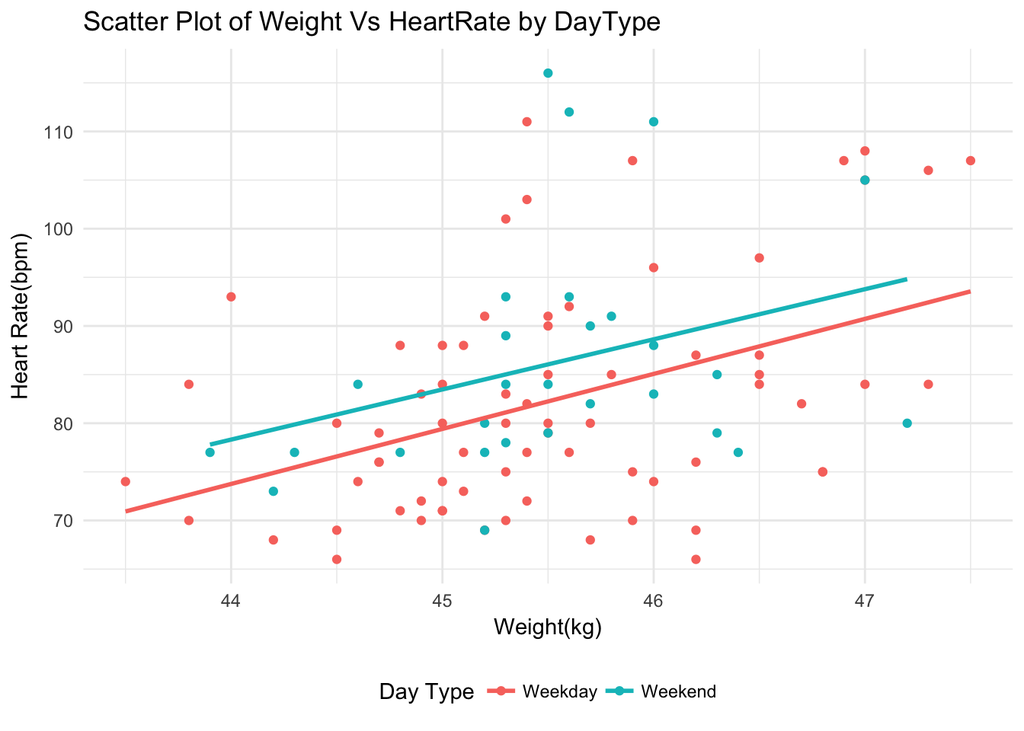

```r
plot_scatter(data = mydata,x = "Weight",y = "HeartRate", color = "DayType")
```

From the above scatter plot, it seems that there is a positive linear relationship between weight and heart rate. And the slopes of weekday and weekend is very similar.

### Checking statistically significantly mean difference across the groups

Now let’s check weather there is statistically significantly difference on average sleep duration between weekday and weekend. We are using oneway-anova test so it is made strong assumption that the dependent variable observation is normal distributed and do not have outliers.

**H0: The mean of sleep duration between weekday and weekend are equal**

**H1: The mean between the two groups are not equal**

```r
summary(aov(SleepDuration ~ DayType, data = mydata ))
```

```
##             Df Sum Sq Mean Sq F value   Pr(>F)
## DayType      1  55.55   55.55    24.8 2.76e-06 ***
## Residuals   97 217.25    2.24
## ---
## Signif. codes:  0 '***' 0.001 '**' 0.01 '*' 0.05 '.' 0.1 ' ' 1
```

From the above testing results, the p-value for this test is far less than the 0.05 significant level. So we reject the null hypothesis and conclude that there is significant difference in the average sleep duration between weekday and weekend under 95% confidence.

We again did the oneway-anova test on the sleep duration between having a dog and not having a dog.

**H0: The mean of sleep duration between having a dog or not are equal**

**H1: The mean between the two groups are not equal**

```r
summary(aov(SleepDuration ~ HavingDog, data = mydata))
```

```
##             Df Sum Sq Mean Sq F value Pr(>F)
## HavingDog    1   0.79  0.7915   0.282  0.596
## Residuals   97 272.01  2.8043
```

Since the p-value is larger than the 0.05 significant level, we fail to reject the null hypotheis that the mean of sleep duration between having a dog or not having a dog are equal. So there is no significant differences of sleep duration on weather having a dog or not on average under given data and evidence , with 95 % confidence.

I also wonder weather having a dog or not will lead to mean differences on my activity level.

```r
summary(aov(Activity~ HavingDog, data = mydata))
```

```
##             Df    Sum Sq   Mean Sq F value   Pr(>F)
## HavingDog    1 565300288 565300288    84.8 6.85e-15 ***
## Residuals   97 646609803   6666080
## ---
## Signif. codes:  0 '***' 0.001 '**' 0.01 '*' 0.05 '.' 0.1 ' ' 1
```

The p-value is far less than 0.05, which means there is siginifiant difference of activity steps on average weather having a dog or not.

## Correlation Matrix Plot

In the dataset, the weight , SleepDuration, Tempreture, Activity and Heart Rate are continues variables. So we can do a multiple correlation analysis on those continues variables to check the pair relationship. We can use the function *cor_plot* in “sha” package to calculate all the pair correlation among all the continues variable as *cor_plot* will automatically detect the continues variables and visulize the results in a plot. (see below)

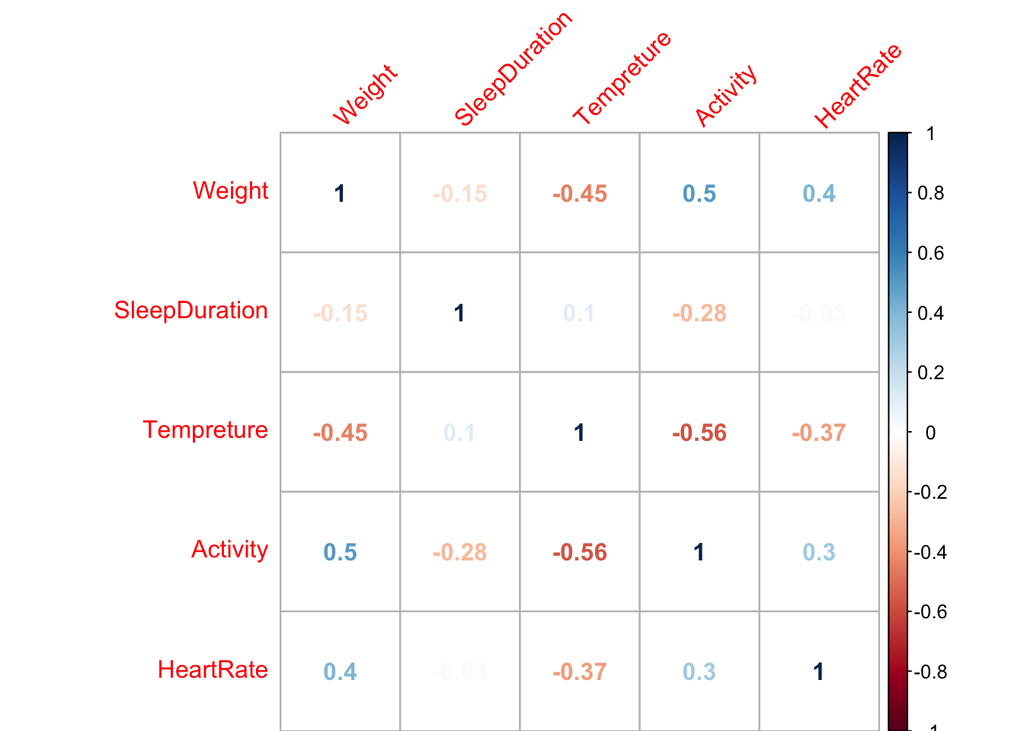

```r
cor_plot(mydata)
```

Additionally, we can use **tidyverse** library to calculate the correlation between two continues variables by set more condtions. For example, we are interested in the correlation between the sleep duration and the tempreture separately for each day type only for having a dog condition, and return a sorted list of those correlation coeffients rounded to two digits.

```r
ans <- mydata %>%
  filter(HavingDog == "Yes") %>%
  group_by(DayType) %>%
  summarise(r = cor(SleepDuration, Tempreture)) %>%
  mutate(r = round(r, 2)) %>%
  arrange(desc(r))

knitr::kable(ans, format = "markdown", align = "l")
```

| DayType | r |
| --- | --- |
| Weekend | 0.05 |
| Weekday | -0.17 |

So the results is quite interesting as there is positive correlation between sleep duration and tempreture on weekend and there is negative correlation between them on weekday when I have a dog. However, both of the correlation coefficent are close to zero. So such association may not siginificant exist.

# Modelling

### Simple Linear Regression Model

According to the above correlation results, we could conduct a simple linear regression models to quantify the association between heart rate and tempreture.

```r
slm_model <- slm_s(mydata, x = "Tempreture", y="HeartRate")
slm_model
```

```
##
## Call:
## lm(formula = data[[y]] ~ data[[x]])
##
## Residuals:
##     Min      1Q  Median      3Q     Max
## -21.379  -6.879  -1.878   3.747  32.626
##
## Coefficients:
##             Estimate Std. Error t value Pr(>|t|)
## (Intercept)  88.3792     1.6700  52.921  < 2e-16 ***
## data[[x]]    -0.5003     0.1258  -3.977 0.000134 ***
## ---
## Signif. codes:  0 '***' 0.001 '**' 0.01 '*' 0.05 '.' 0.1 ' ' 1
##
## Residual standard error: 11.07 on 97 degrees of freedom
## Multiple R-squared:  0.1402, Adjusted R-squared:  0.1313
## F-statistic: 15.82 on 1 and 97 DF,  p-value: 0.0001344
```

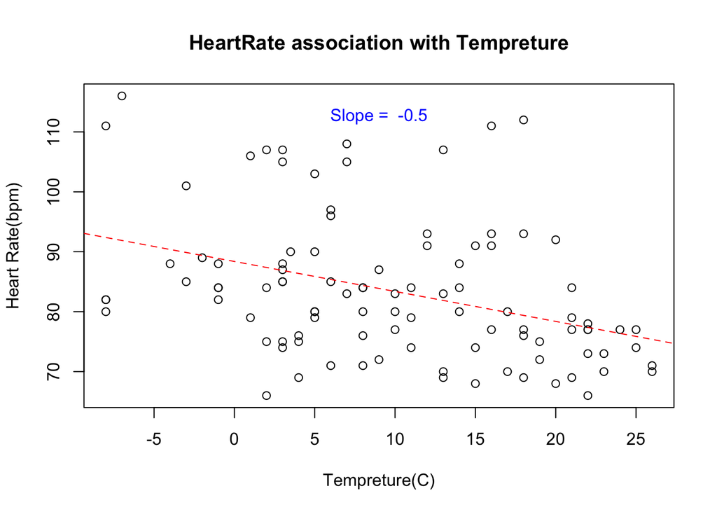

```r
modelplot(mydata, x = "Tempreture", y="HeartRate")
```

The equation of the above linear model can be constructed from the output:

**Predicted Heart Rate =** 88.38 **+ (**-0.5**) * Tempreture**

The interpretation for the slope coefficient: With a unit celsius increase in tempreture,the heart rate, on average, decrease by approximately 0.5 bpm.

We can further check the model assumption by Q-Q plot to see if the data are normal distributed.

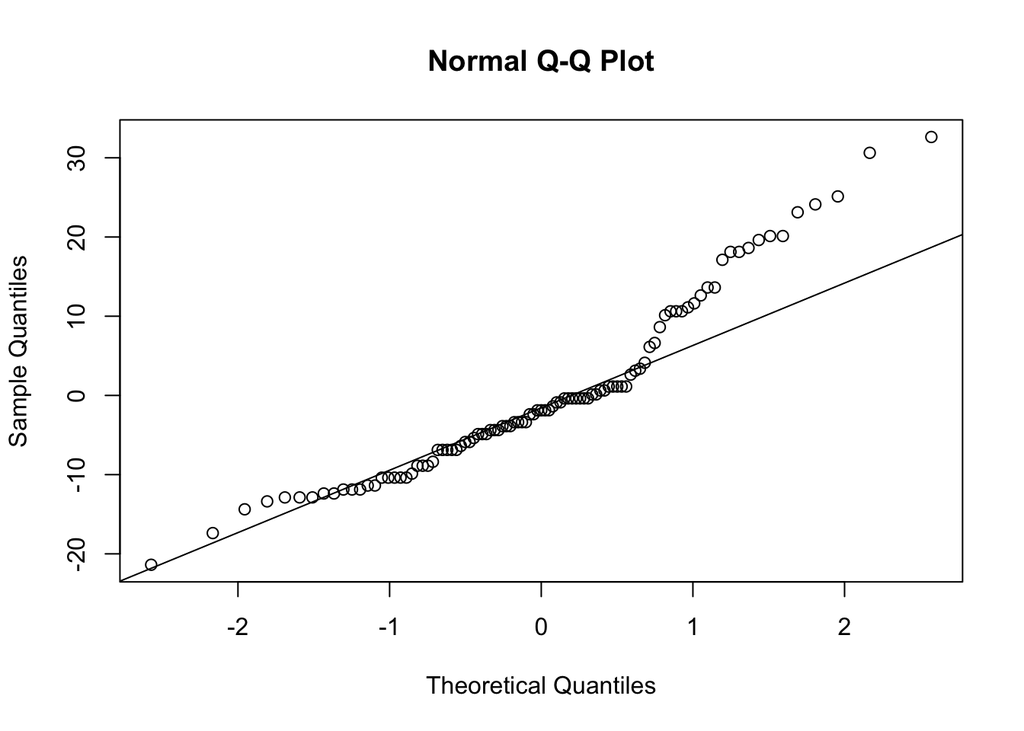

```r
qqnorm(slm_model$residuals)
qqline(slm_model$residuals)
```

It seemes that the data are not follow normal distribution, which violte the the **Normality** assumption. And the tail of the distribution has a lot of outliers, which may have huge impact on the shape of the distribution.

### Multiple Linear Regression Model

Create a scatter matrix plot on all the continues variables.

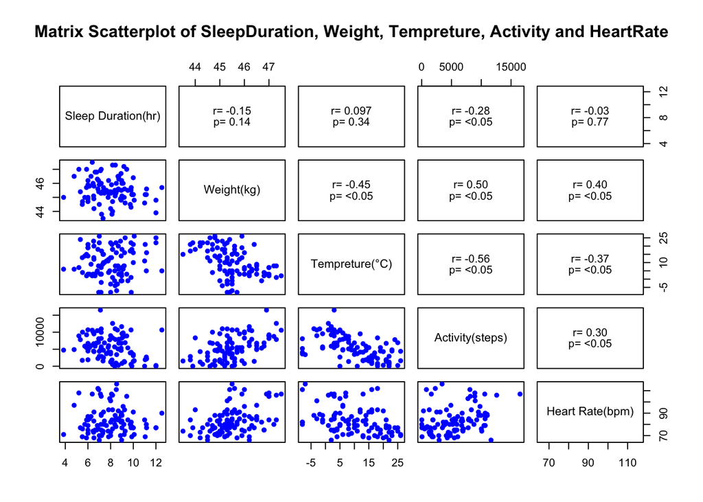

```r
panel.cor <- function(x, y, digits = 2, cex.cor, ...)
{
  usr <- par("usr"); on.exit(par(usr))
  par(usr = c(0, 1, 0, 1))
  # correlation coefficient
  r <- cor(x, y)
  txt <- format(c(r, 0.123456789), digits = digits)[1]
  txt <- paste("r= ", txt, sep = "")
  text(0.5, 0.6, txt)

  # p-value calculation
  p <- cor.test(x, y)$p.value
  txt2 <- format(c(p, 0.123456789), digits = digits)[1]
  txt2 <- paste("p= ", txt2, sep = "")
  if(p<0.05) txt2 <- paste("p= ", "<0.05", sep = "")
  text(0.5, 0.4, txt2)
}
par(ps = 12, cex = 1, cex.main = 1)
pairs(mydata %>% select(SleepDuration, Weight, Tempreture, Activity, HeartRate), upper.panel = panel.cor,
      pch=16, col="blue", main="Matrix Scatterplot of SleepDuration, Weight, Tempreture, Activity and HeartRate", labels = c("Sleep Duration(hr)","Weight(kg)","Tempreture(°C)","Activity(steps)","Heart Rate(bpm)"))
```

From the above graph, the variables seems that corrlated to each other, so it may arise multicollinearity problem. Also, the correlation between sleep duration and acitivity by steps are significant, while the rest of variables with sleep duration correlation is not siginifiicant.

Creating a multiple linear regression model included all variables except the date, becasue the date is a distinct identifier, like index.

```r
ml.saturated = lm(SleepDuration ~  Weight + Tempreture + HeartRate + Activity + DayType + HavingDog,
                  data= mydata)
mlr_sum <- summary(ml.saturated)
mlr_sum
```

```
##
## Call:
## lm(formula = SleepDuration ~ Weight + Tempreture + HeartRate +
##     Activity + DayType + HavingDog, data = mydata)
##
## Residuals:
##     Min      1Q  Median      3Q     Max
## -3.3454 -1.1216 -0.0497  1.0446  3.7116
##
## Coefficients:
##                  Estimate Std. Error t value Pr(>|t|)
## (Intercept)     1.863e+01  9.723e+00   1.916   0.0585 .
## Weight         -2.387e-01  2.215e-01  -1.078   0.2840
## Tempreture      2.977e-02  2.817e-02   1.057   0.2933
## HeartRate      -2.201e-03  1.407e-02  -0.156   0.8761
## Activity       -1.511e-04  5.927e-05  -2.549   0.0124 *
## DayTypeWeekend  1.525e+00  3.345e-01   4.558 1.59e-05 ***
## HavingDogYes    1.221e+00  5.901e-01   2.069   0.0413 *
## ---
## Signif. codes:  0 '***' 0.001 '**' 0.01 '*' 0.05 '.' 0.1 ' ' 1
##
## Residual standard error: 1.452 on 92 degrees of freedom
## Multiple R-squared:  0.2893, Adjusted R-squared:  0.2429
## F-statistic: 6.241 on 6 and 92 DF,  p-value: 1.579e-05
```

```r
knitr::kable(mlr_sum $coef, digits = c(4, 4, 3, 4), format = 'markdown')
```

|  | Estimate | Std. Error | t value | Pr(>\|t\|) |
| --- | --- | --- | --- | --- |
| (Intercept) | 18.6298 | 9.7235 | 1.916 | 0.0585 |
| Weight | -0.2387 | 0.2215 | -1.078 | 0.2840 |
| Tempreture | 0.0298 | 0.0282 | 1.057 | 0.2933 |
| HeartRate | -0.0022 | 0.0141 | -0.156 | 0.8761 |
| Activity | -0.0002 | 0.0001 | -2.549 | 0.0124 |
| DayTypeWeekend | 1.5245 | 0.3345 | 4.558 | 0.0000 |
| HavingDogYes | 1.2211 | 0.5901 | 2.069 | 0.0413 |

Although some of p-value of the attributes are less than 0.05, the overall regression is significant as the p-value is far less than 0.05.